# Part II - Ford GoBike System Data Analysis

## by Lamia Alshoaibi

## Investigation Overview

One of the main goals of data visualization in the data analysis process is to give support in making decision through appropriately designed graphically represented information. In this project, I used Python libraries such as NumPy, pandas, Matplotlib, and Seaborn to do the exploratory and explanatory analysis of Ford GoBike data to communicate my results.

The presentation will focus on how user type and gender impact the trip duration of Ford Gobikes.

- Customers took longer time to complete the trip than subscribers.
- When analyzing the day of weeks, subscribers tends to use the service in weekdays.
- Regardless of the user type, males appear to complete the trip faster than females.

## Dataset Overview

The Ford GoBike dataset includes information about individual rides made in a bike-sharing system covering the greater San Francisco Bay area during the month of February. In particular, the data contained the following features: Duration In Secounds, Start Station ID, Start Station Name, Start Station Latitude, Start Station Longitude, End Station ID, End Station Name, End Station Latitude, End Station Longitude, Bike ID, User Type (Subscriber or Customer), Member Year of Birth and Member Gender.

## Distribution of trip duration for each user type

How long does the average trip duration take for each user type? As shown on plot below, the customers average trip duration is almost 15 minutes and subscribers average trip duration is almost 10 minutes.

*note: The trips duration of the dataset covering range from almost one minute to 60 minutes.

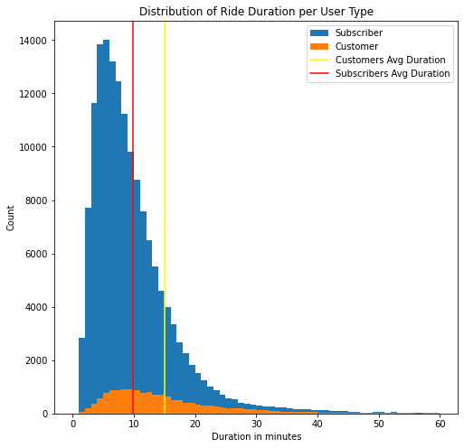

## Consumption of daily trips per user type

Who is more consumption of daily trips?Customers or subscripers? In general, bike trip patterns were different on weekdays than on weekends. There is higher frequency of bike trips on weekdays than on weekends, and most of the trips started on Tuesday and Thursday. And as shown on the plot, subscripers has the most trips on daily usage than customers and used the service on weekdays more than weekends. Which makes us assume that subscribers used GoBike service for work while customers used it for entertainment.

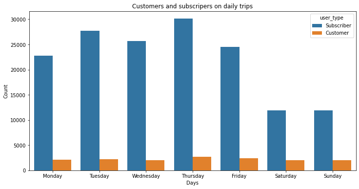

## Comparison of trip durations between customers and subscribers for each gender

Do customers take longer bike trips than subscribers? The box plot showed that customers take longer trip durations than subscribers. and regardless of the user type, male appear to complete the trip faster than females.

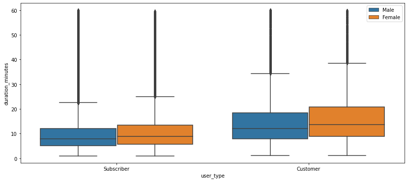

## Distribution of trip durations per user type on each day of week

Do customers take longer bike trips on average than subscribers throughout the day? The box plot below affirms that customers take longer bike trips on average regardless of the day of week.

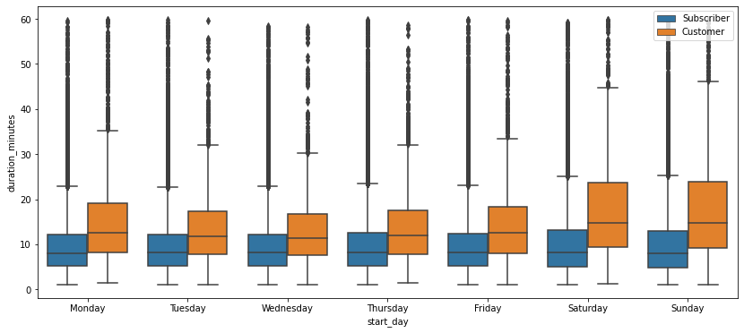